# PREDICCIÓN DELICTIVA EN EL METRO DE LA CIUDAD DE MÉXICO

## Introducción

El Metro de la Ciudad de México es un transporte usado diariamente por muchas personas para realizar sus actividades cotidianas. Sin embargo, el incremento en la incidencia delictiva dentro y en los alrededores de sus instalaciones ha provocado que la gente se sienta insegura.

## Objetivo

El objetivo de este trabajo es predecir la frecuencia delictiva en las estaciones del Sistema de Transporte Colectivo Metro ocupando el día de la semana, línea del metro, tipo de estación, y afluencia promedio.

## Justificación

Desde una perspectiva social, esta investigación y análisis estadístico son relevantes porque se centran en la seguridad de los usuarios del transporte público en una de las ciudades más grandes del mundo. Asegurar la seguridad en el transporte público es fundamental, ya que impacta directamente en la calidad de vida de los ciudadanos, sus decisiones de movilidad y, en consecuencia, sus gastos en transporte.

```python
time_dim = pd.read_csv('./time_dimension_final.csv',
                 sep=',', engine='python', encoding="UTF-8")
```

```python
sub_stations_dim = pd.read_csv('./subway_stations_dimension_final.csv',
                 sep=',', engine='python', encoding="UTF-8")
```

```python
crimes_dim = pd.read_csv('./crimes_dimension_final_fixed.csv',
                 sep=',', engine='python', encoding="UTF-8")
```

```python
crimes_category_dim = pd.read_csv('./crimes_category_dimension_final.csv',
                 sep=',', engine='python', encoding="UTF-8")
```

```python
sex_dim = pd.read_csv('./sex_dimension_final.csv',
                 sep=',', engine='python', encoding="UTF-8")
```

## Unión con la tabla de hechos de carpetas de investigación

```python
crimes_ft = pd.read_csv('./crimes_folders_fact_table_final_fixed.csv',
                 sep=',', engine='python', encoding="UTF-8")
```

```python
crimes_ft = crimes_ft.merge(time_dim, how='inner', on='id_time')
```

```python
crimes_ft = crimes_ft.merge(sub_stations_dim, how='inner', on='id_station')
```

```python
crimes_ft = crimes_ft.merge(crimes_dim, how='inner', on='id_crimes')
```

```python
crimes_ft = crimes_ft.merge(crimes_category_dim, how='inner', on='id_crime_category')
```

```python
crimes_ft.head(3)
```

|  | id_crime_folder | id_station | id_time | id_space_x | id_crimes | id_sex | year | quarter | month | week | weekday | day | hour | id_space_y | type | line | name | id_crime_category | crime | crime_category |
| --- | --- | --- | --- | --- | --- | --- | --- | --- | --- | --- | --- | --- | --- | --- | --- | --- | --- | --- | --- | --- |
| 0 | 1 | STC0101 | 2019010307 | 186 | 212 | 0 | 2019 | 1 | 1 | 1 | 3 | 3 | 7 | 1 | Terminal / Transbordo | 1 | Pantitlán | 13 | ROBO A PASAJERO A BORDO DE METRO SIN VIOLENCIA | ROBO A PASAJERO A BORDO DEL METRO CON Y SIN VI... |
| 1 | 2 | STC0101 | 2019010317 | 187 | 212 | 0 | 2019 | 1 | 1 | 1 | 3 | 3 | 17 | 1 | Terminal / Transbordo | 1 | Pantitlán | 13 | ROBO A PASAJERO A BORDO DE METRO SIN VIOLENCIA | ROBO A PASAJERO A BORDO DEL METRO CON Y SIN VI... |
| 2 | 4 | STC0101 | 2019010512 | 189 | 212 | 0 | 2019 | 1 | 1 | 1 | 5 | 5 | 12 | 1 | Terminal / Transbordo | 1 | Pantitlán | 13 | ROBO A PASAJERO A BORDO DE METRO SIN VIOLENCIA | ROBO A PASAJERO A BORDO DEL METRO CON Y SIN VI... |

## Graficamos cantidad de carpetas de investigación por categoría delictiva

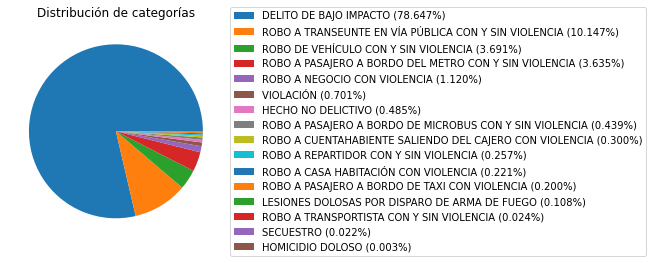

```python
# Obtener los conteos por categoría
conteos = crimes_ft['crime_category'].value_counts()

# Calcular los porcentajes de cada categoría
porcentajes = conteos / len(crimes_ft) * 100

# Crear la gráfica de pastel sin los nombres superpuestos
plt.pie(conteos, labels=None, autopct='')

# Configurar el título de la gráfica
plt.title('Distribución de categorías')

# Obtener los nombres de las categorías y porcentajes como una lista de strings
leyenda_texto = [f'{categoria} ({porcentaje:.3f}%)' for categoria, porcentaje in zip(conteos.index, porcentajes)]

# Agregar leyenda con los nombres de las categorías y porcentajes
plt.legend(leyenda_texto, loc='center left', bbox_to_anchor=(1, 0.5))

plt.show()
```

## Unión con la tabla de hechos de afluencia del metro

```python
afluency_ft = pd.read_csv('./afluency_fact_table_final.csv',
                 sep=',', engine='python', encoding="UTF-8")
```

```python
afluency_ft = afluency_ft.merge(time_dim, how='inner', on='id_time')
```

```python
afluency_ft = afluency_ft.merge(sub_stations_dim, how='inner', on='id_station')
```

```python
afluency_ft.head(3)
```

|  | id_afluency | id_station | id_time | afluency_distribution | year | quarter | month | week | weekday | day | hour | id_space | type | line | name |
| --- | --- | --- | --- | --- | --- | --- | --- | --- | --- | --- | --- | --- | --- | --- | --- |
| 0 | 1 | STC0101 | 2019010100 | 71.0 | 2019 | 1 | 1 | 1 | 1 | 1 | 0 | 1 | Terminal / Transbordo | 1 | Pantitlán |
| 1 | 186 | STC0101 | 2019010101 | 0.0 | 2019 | 1 | 1 | 1 | 1 | 1 | 1 | 1 | Terminal / Transbordo | 1 | Pantitlán |
| 2 | 371 | STC0101 | 2019010102 | 0.0 | 2019 | 1 | 1 | 1 | 1 | 1 | 2 | 1 | Terminal / Transbordo | 1 | Pantitlán |

```python
afluency_aux = afluency_ft.groupby(['id_station', 'line', 'type', 'year', 'month', 'weekday', 'day'])[['afluency_distribution']].sum().reset_index()
```

```python
afluency_aux = afluency_aux.groupby(['line', 'weekday'])[['afluency_distribution']].mean().reset_index()
```

```python
afluency_aux
```

|  | line | weekday | afluency_distribution |
| --- | --- | --- | --- |
| 0 | 1 | 0 | 23834.501603 |
| 1 | 1 | 1 | 24233.241401 |
| 2 | 1 | 2 | 24297.878344 |
| 3 | 1 | 3 | 24327.839809 |
| 4 | 1 | 4 | 24667.462102 |
| ... | ... | ... | ... |
| 79 | B | 2 | 11484.712886 |
| 80 | B | 3 | 11472.159236 |
| 81 | B | 4 | 11654.321901 |
| 82 | B | 5 | 11347.039448 |
| 83 | B | 6 | 8271.556706 |

84 rows × 3 columns

```python
lines_unique = afluency_aux.line.unique()
lines_unique
```

```
array(['1', '12', '2', '3', '4', '5', '6', '7', '8', '9', 'A', 'B'],
      dtype=object)
```

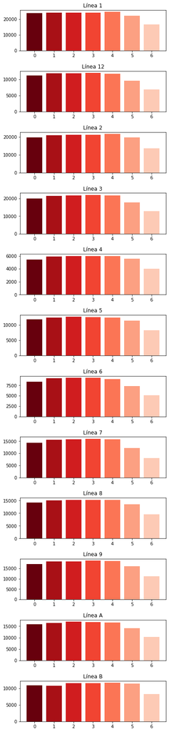

```python
fig, ax = plt.subplots(12, figsize=(6, 30))
plt.subplots_adjust(hspace=0.5)
for i in range(12):
    # Filtramos dataset
    afluency_aux_line = afluency_aux[afluency_aux['line'] == lines_unique[i]]
    weekdays = afluency_aux_line['weekday']
    afluency_dist = afluency_aux_line['afluency_distribution']
    max_valor = max(afluency_dist)
    colores = np.flipud(plt.cm.Reds(np.linspace(0.2, 1, len(afluency_dist))))

    # Crear el gráfico de barras utilizando plt.plot()
    ax[i].bar(weekdays, afluency_dist, color=colores)
    ax[i].set_title('Línea ' + lines_unique[i])
```

## Agrupamiento de carpetas delictivas por día

```python
crimes_ft_aux = crimes_ft[['line', 'type', 'year', 'month', 'weekday', 'day', 'id_crime_category']]
```

```python
crimes_ft_grouped_day = crimes_ft_aux.groupby(['line', 'type', 'year', 'month', 'weekday', 'day', 'id_crime_category']).size().reset_index(name = 'frequency')
```

```python
crimes_ft_grouped_day
```

|  | line | type | year | month | weekday | day | id_crime_category | frequency |
| --- | --- | --- | --- | --- | --- | --- | --- | --- |
| 0 | 1 | Intermedia | 2019 | 1 | 0 | 7 | 5 | 4 |
| 1 | 1 | Intermedia | 2019 | 1 | 0 | 7 | 6 | 12 |
| 2 | 1 | Intermedia | 2019 | 1 | 0 | 7 | 14 | 1 |
| 3 | 1 | Intermedia | 2019 | 1 | 0 | 14 | 5 | 1 |
| 4 | 1 | Intermedia | 2019 | 1 | 0 | 14 | 6 | 22 |
| ... | ... | ... | ... | ... | ... | ... | ... | ... |
| 57830 | B | Transbordo | 2021 | 11 | 3 | 4 | 6 | 3 |
| 57831 | B | Transbordo | 2021 | 11 | 3 | 4 | 8 | 1 |
| 57832 | B | Transbordo | 2021 | 11 | 5 | 6 | 6 | 3 |
| 57833 | B | Transbordo | 2021 | 11 | 6 | 7 | 5 | 1 |
| 57834 | B | Transbordo | 2021 | 11 | 6 | 7 | 6 | 4 |

57835 rows × 8 columns

## Agrupamiento de afluencia de metro por día

Se hace la suma de afluencia por estación (ya que venía por hora)

```python
afluency_ft_grouped_day = afluency_ft.groupby(['id_station', 'line', 'type', 'year', 'month', 'weekday', 'day'])[['afluency_distribution']].sum().reset_index()
```

```python
afluency_ft_grouped_day.head(3)
```

|  | id_station | line | type | year | month | weekday | day | afluency_distribution |
| --- | --- | --- | --- | --- | --- | --- | --- | --- |
| 0 | STC0101 | 1 | Terminal / Transbordo | 2019 | 1 | 0 | 7 | 36314.0 |
| 1 | STC0101 | 1 | Terminal / Transbordo | 2019 | 1 | 0 | 14 | 33633.0 |
| 2 | STC0101 | 1 | Terminal / Transbordo | 2019 | 1 | 0 | 21 | 34692.0 |

Se promedia afluencia diaria por tipo de estación y línea

```python
afluency_ft_grouped_day = afluency_ft_grouped_day.groupby(['line', 'type', 'year', 'month', 'weekday', 'day'])[['afluency_distribution']].mean().reset_index()
```

```python
afluency_ft_grouped_day.sort_values(by = ['year', 'month', 'day'], inplace = True)
```

```python
afluency_ft_grouped_day
```

|  | line | type | year | month | weekday | day | afluency_distribution |
| --- | --- | --- | --- | --- | --- | --- | --- |
| 4 | 1 | Intermedia | 2019 | 1 | 1 | 1 | 11130.083333 |
| 1100 | 1 | Terminal | 2019 | 1 | 1 | 1 | 40846.000000 |
| 2196 | 1 | Terminal / Transbordo | 2019 | 1 | 1 | 1 | 14452.000000 |
| 3292 | 1 | Transbordo | 2019 | 1 | 1 | 1 | 12372.000000 |
| 4388 | 12 | Intermedia | 2019 | 1 | 1 | 1 | 5251.600000 |
| ... | ... | ... | ... | ... | ... | ... | ... |
| 39447 | A | Intermedia | 2021 | 12 | 4 | 31 | 12522.428571 |
| 40543 | A | Terminal / Transbordo | 2021 | 12 | 4 | 31 | 17066.000000 |
| 41639 | B | Intermedia | 2021 | 12 | 4 | 31 | 9608.857143 |
| 42735 | B | Terminal | 2021 | 12 | 4 | 31 | 31031.000000 |
| 43831 | B | Transbordo | 2021 | 12 | 4 | 31 | 5209.600000 |

43840 rows × 7 columns

## Ajustes para indicarle cuando no existió delito (asignarle cero)

Se agrega columna comodín ('key' = 0), para hacer producto cartesiano con los valores de las dimensiones

```python
afluency_ft_grouped_day['key'] = 0
```

Seleccionamos solo las categorísa delictivas más frecuentes

```python
crimes_ft[['id_crime_category', 'crime_category']].value_counts()
```

```
id_crime_category  crime_category
6                  DELITO DE BAJO IMPACTO                                     135466
5                  ROBO A TRANSEUNTE EN VÍA PÚBLICA CON Y SIN VIOLENCIA        17477
7                  ROBO DE VEHÍCULO CON Y SIN VIOLENCIA                         6358
13                 ROBO A PASAJERO A BORDO DEL METRO CON Y SIN VIOLENCIA        6261
11                 ROBO A NEGOCIO CON VIOLENCIA                                 1929
8                  VIOLACIÓN                                                    1208
1                  HECHO NO DELICTIVO                                            836
2                  ROBO A PASAJERO A BORDO DE MICROBUS CON Y SIN VIOLENCIA       756
14                 ROBO A CUENTAHABIENTE SALIENDO DEL CAJERO CON VIOLENCIA       516
16                 ROBO A REPARTIDOR CON Y SIN VIOLENCIA                         442
4                  ROBO A CASA HABITACIÓN CON VIOLENCIA                          381
3                  ROBO A PASAJERO A BORDO DE TAXI CON VIOLENCIA                 344
15                 LESIONES DOLOSAS POR DISPARO DE ARMA DE FUEGO                 186
10                 ROBO A TRANSPORTISTA CON Y SIN VIOLENCIA                       42
9                  SECUESTRO                                                      38
12                 HOMICIDIO DOLOSO                                                6
dtype: int64
```

```python
crimes_category_dim
```

|  | id_crime_category | crime_category |
| --- | --- | --- |
| 0 | 1 | HECHO NO DELICTIVO |
| 1 | 2 | ROBO A PASAJERO A BORDO DE MICROBUS CON Y SIN ... |
| 2 | 3 | ROBO A PASAJERO A BORDO DE TAXI CON VIOLENCIA |
| 3 | 4 | ROBO A CASA HABITACIÓN CON VIOLENCIA |
| 4 | 5 | ROBO A TRANSEUNTE EN VÍA PÚBLICA CON Y SIN VIO... |
| 5 | 6 | DELITO DE BAJO IMPACTO |
| 6 | 7 | ROBO DE VEHÍCULO CON Y SIN VIOLENCIA |
| 7 | 8 | VIOLACIÓN |
| 8 | 9 | SECUESTRO |
| 9 | 10 | ROBO A TRANSPORTISTA CON Y SIN VIOLENCIA |
| 10 | 11 | ROBO A NEGOCIO CON VIOLENCIA |
| 11 | 12 | HOMICIDIO DOLOSO |
| 12 | 13 | ROBO A PASAJERO A BORDO DEL METRO CON Y SIN VI... |
| 13 | 14 | ROBO A CUENTAHABIENTE SALIENDO DEL CAJERO CON ... |
| 14 | 15 | LESIONES DOLOSAS POR DISPARO DE ARMA DE FUEGO |
| 15 | 16 | ROBO A REPARTIDOR CON Y SIN VIOLENCIA |

```python
crimes_category_dim_aux = crimes_category_dim[(crimes_category_dim['id_crime_category'].isin([5, 6, 7, 11, 13]))]
```

```python
crimes_category_dim_aux = crimes_category_dim_aux[['id_crime_category', 'key']]
```

```python
crimes_category_dim_aux
```

|  | id_crime_category | key |
| --- | --- | --- |
| 4 | 5 | 0 |
| 5 | 6 | 0 |
| 6 | 7 | 0 |
| 10 | 11 | 0 |
| 12 | 13 | 0 |

```python
afluency_ft_grouped_day_expanded = afluency_ft_grouped_day.merge(crimes_category_dim_aux, how = 'outer')
```

```python
afluency_ft_grouped_day_expanded.drop(columns = ['key'], inplace = True)
```

```python
len(afluency_ft_grouped_day_expanded)
```

```
219200
```

```python
afluency_ft_grouped_day_expanded.head(3)
```

|  | line | type | year | month | weekday | day | afluency_distribution | id_crime_category |
| --- | --- | --- | --- | --- | --- | --- | --- | --- |
| 0 | 1 | Intermedia | 2019 | 1 | 1 | 1 | 11130.083333 | 5 |
| 1 | 1 | Intermedia | 2019 | 1 | 1 | 1 | 11130.083333 | 6 |
| 2 | 1 | Intermedia | 2019 | 1 | 1 | 1 | 11130.083333 | 7 |

```python
len(afluency_ft_grouped_day_expanded)
```

```
219200
```

```python
crimes_ft_grouped_day.head(3)
```

|  | line | type | year | month | weekday | day | id_crime_category | frequency |
| --- | --- | --- | --- | --- | --- | --- | --- | --- |
| 0 | 1 | Intermedia | 2019 | 1 | 0 | 7 | 5 | 4 |
| 1 | 1 | Intermedia | 2019 | 1 | 0 | 7 | 6 | 12 |
| 2 | 1 | Intermedia | 2019 | 1 | 0 | 7 | 14 | 1 |

```python
len(crimes_ft_grouped_day)
```

```
57835
```

```python
crimes_afluency_ft = afluency_ft_grouped_day_expanded.merge(crimes_ft_grouped_day,
                        on = ['line', 'type', 'year', 'weekday', 'month', 'day', 'id_crime_category'], how = 'left')
```

```python
crimes_afluency_ft
```

|  | line | type | year | month | weekday | day | afluency_distribution | id_crime_category | frequency |
| --- | --- | --- | --- | --- | --- | --- | --- | --- | --- |
| 0 | 1 | Intermedia | 2019 | 1 | 1 | 1 | 11130.083333 | 5 | 1.0 |
| 1 | 1 | Intermedia | 2019 | 1 | 1 | 1 | 11130.083333 | 6 | 10.0 |
| 2 | 1 | Intermedia | 2019 | 1 | 1 | 1 | 11130.083333 | 7 | NaN |
| 3 | 1 | Intermedia | 2019 | 1 | 1 | 1 | 11130.083333 | 11 | NaN |
| 4 | 1 | Intermedia | 2019 | 1 | 1 | 1 | 11130.083333 | 13 | 1.0 |
| ... | ... | ... | ... | ... | ... | ... | ... | ... | ... |
| 219195 | B | Transbordo | 2021 | 12 | 4 | 31 | 5209.600000 | 5 | NaN |
| 219196 | B | Transbordo | 2021 | 12 | 4 | 31 | 5209.600000 | 6 | NaN |
| 219197 | B | Transbordo | 2021 | 12 | 4 | 31 | 5209.600000 | 7 | NaN |
| 219198 | B | Transbordo | 2021 | 12 | 4 | 31 | 5209.600000 | 11 | NaN |
| 219199 | B | Transbordo | 2021 | 12 | 4 | 31 | 5209.600000 | 13 | NaN |

219200 rows × 9 columns

```python
crimes_afluency_ft.isna().sum()
```

```
line                          0
type                          0
year                          0
month                         0
weekday                       0
day                           0
afluency_distribution         0
id_crime_category             0
frequency                165682
dtype: int64
```

```python
crimes_afluency_ft['frequency'] = crimes_afluency_ft['frequency'].fillna(0)
```

```python
crimes_afluency_ft
```

|  | line | type | year | month | weekday | day | afluency_distribution | id_crime_category | frequency |
| --- | --- | --- | --- | --- | --- | --- | --- | --- | --- |
| 0 | 1 | Intermedia | 2019 | 1 | 1 | 1 | 11130.083333 | 5 | 1.0 |
| 1 | 1 | Intermedia | 2019 | 1 | 1 | 1 | 11130.083333 | 6 | 10.0 |
| 2 | 1 | Intermedia | 2019 | 1 | 1 | 1 | 11130.083333 | 7 | 0.0 |
| 3 | 1 | Intermedia | 2019 | 1 | 1 | 1 | 11130.083333 | 11 | 0.0 |
| 4 | 1 | Intermedia | 2019 | 1 | 1 | 1 | 11130.083333 | 13 | 1.0 |
| ... | ... | ... | ... | ... | ... | ... | ... | ... | ... |
| 219195 | B | Transbordo | 2021 | 12 | 4 | 31 | 5209.600000 | 5 | 0.0 |
| 219196 | B | Transbordo | 2021 | 12 | 4 | 31 | 5209.600000 | 6 | 0.0 |
| 219197 | B | Transbordo | 2021 | 12 | 4 | 31 | 5209.600000 | 7 | 0.0 |
| 219198 | B | Transbordo | 2021 | 12 | 4 | 31 | 5209.600000 | 11 | 0.0 |
| 219199 | B | Transbordo | 2021 | 12 | 4 | 31 | 5209.600000 | 13 | 0.0 |

219200 rows × 9 columns

```python
crimes_afluency_ft_filtered = crimes_afluency_ft[['line', 'type', 'weekday', 'id_crime_category', 'afluency_distribution', 'frequency']]
```

```python
crimes_afluency_ft_filtered = crimes_afluency_ft_filtered.rename(columns = {'frequency': 'crime_frequency'})
```

```python
crimes_afluency_ft_filtered
```

|  | line | type | weekday | id_crime_category | afluency_distribution | crime_frequency |
| --- | --- | --- | --- | --- | --- | --- |
| 0 | 1 | Intermedia | 1 | 5 | 11130.083333 | 1.0 |
| 1 | 1 | Intermedia | 1 | 6 | 11130.083333 | 10.0 |
| 2 | 1 | Intermedia | 1 | 7 | 11130.083333 | 0.0 |
| 3 | 1 | Intermedia | 1 | 11 | 11130.083333 | 0.0 |
| 4 | 1 | Intermedia | 1 | 13 | 11130.083333 | 1.0 |
| ... | ... | ... | ... | ... | ... | ... |
| 219195 | B | Transbordo | 4 | 5 | 5209.600000 | 0.0 |
| 219196 | B | Transbordo | 4 | 6 | 5209.600000 | 0.0 |
| 219197 | B | Transbordo | 4 | 7 | 5209.600000 | 0.0 |
| 219198 | B | Transbordo | 4 | 11 | 5209.600000 | 0.0 |
| 219199 | B | Transbordo | 4 | 13 | 5209.600000 | 0.0 |

219200 rows × 6 columns

## Graficamos frecuencia delictiva incluyendo ceros

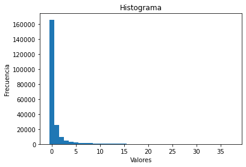

```python
column = crimes_afluency_ft_filtered['crime_frequency'].astype(int)
plt.hist(column, bins=range(column.min(), column.max() + 2), align='left')
plt.xlabel('Valores')
plt.ylabel('Frecuencia')
plt.title('Histograma')
plt.show()
```

```python
crimes_afluency_ft_filtered.to_csv('data_crimes_afluency_line_type.csv', encoding = 'utf-8', index = False)
```